# Part I - Loan Data from Prosper

## Introduction

1. Who borrow money through Prosper? Why do they want a loan?
2. What affects the borrower’s APR or interest rate?

## Preliminary Wrangling

```python
# import all packages and set plots to be embedded inline
import numpy as np
import pandas as pd
import matplotlib.pyplot as plt
import seaborn as sns

%matplotlib inline
```

```python
LoanData = pd.read_csv('prosperLoanData.csv')
LoanData.head()
```

|  | ListingKey | ListingNumber | ListingCreationDate | CreditGrade | Term | LoanStatus | ClosedDate | BorrowerAPR | BorrowerRate | LenderYield | ... | LP_ServiceFees | LP_CollectionFees | LP_GrossPrincipalLoss | LP_NetPrincipalLoss | LP_NonPrincipalRecoverypayments | PercentFunded | Recommendations | InvestmentFromFriendsCount | InvestmentFromFriendsAmount | Investors |
| --- | --- | --- | --- | --- | --- | --- | --- | --- | --- | --- | --- | --- | --- | --- | --- | --- | --- | --- | --- | --- | --- |
| 0 | 1021339766868145413AB3B | 193129 | 2007-08-26 19:09:29.263000000 | C | 36 | Completed | 2009-08-14 00:00:00 | 0.16516 | 0.1580 | 0.1380 | ... | -133.18 | 0.0 | 0.0 | 0.0 | 0.0 | 1.0 | 0 | 0 | 0.0 | 258 |
| 1 | 10273602499503308B223C1 | 1209647 | 2014-02-27 08:28:07.900000000 | NaN | 36 | Current | NaN | 0.12016 | 0.0920 | 0.0820 | ... | 0.00 | 0.0 | 0.0 | 0.0 | 0.0 | 1.0 | 0 | 0 | 0.0 | 1 |
| 2 | 0EE9337825851032864889A | 81716 | 2007-01-05 15:00:47.090000000 | HR | 36 | Completed | 2009-12-17 00:00:00 | 0.28269 | 0.2750 | 0.2400 | ... | -24.20 | 0.0 | 0.0 | 0.0 | 0.0 | 1.0 | 0 | 0 | 0.0 | 41 |
| 3 | 0EF5356002482715299901A | 658116 | 2012-10-22 11:02:35.010000000 | NaN | 36 | Current | NaN | 0.12528 | 0.0974 | 0.0874 | ... | -108.01 | 0.0 | 0.0 | 0.0 | 0.0 | 1.0 | 0 | 0 | 0.0 | 158 |
| 4 | 0F023589499656230C5E3E2 | 909464 | 2013-09-14 18:38:39.097000000 | NaN | 36 | Current | NaN | 0.24614 | 0.2085 | 0.1985 | ... | -60.27 | 0.0 | 0.0 | 0.0 | 0.0 | 1.0 | 0 | 0 | 0.0 | 20 |

5 rows × 81 columns

```python
print(LoanData.shape)
print(LoanData.info())
```

```
(113937, 81)
<class 'pandas.core.frame.DataFrame'>
RangeIndex: 113937 entries, 0 to 113936
Data columns (total 81 columns):
 #   Column                               Non-Null Count   Dtype
---  ------                               --------------   -----
 0   ListingKey                           113937 non-null  object
 1   ListingNumber                        113937 non-null  int64
 2   ListingCreationDate                  113937 non-null  object
 3   CreditGrade                          28953 non-null   object
 4   Term                                 113937 non-null  int64
 5   LoanStatus                           113937 non-null  object
 6   ClosedDate                           55089 non-null   object
 7   BorrowerAPR                          113912 non-null  float64
 8   BorrowerRate                         113937 non-null  float64
```

[output cut: 75 more lines]

There are 81 variables in this dataset and it is not necessary to explore every variable because not every variable are closely related to the answer of the questions asked above. After consideration, I decide to choose 13 variables from the original dataset to carry out my exploration. The rest of the variables will not be considered in this report. The variables to keep are: `ListingNumber`, `ListingCreationDate`, `LoanOriginalAmount`, `LoanStatus`, `ListingCategory (numeric)`, `BorrowerAPR`, `BorrowerRate`, `StatedMonthlyIncome`, `ProsperRating (Alpha)`, `Occupation`, `Term`, `EmploymentStatus`, and `MonthlyLoanPayment`.

```python
cols= ['ListingNumber', 'ListingCreationDate', 'LoanOriginalAmount', 'LoanStatus', 'ListingCategory (numeric)',
       'BorrowerAPR', 'BorrowerRate', 'StatedMonthlyIncome', 'ProsperRating (Alpha)', 'Occupation', 'Term',
       'EmploymentStatus', 'MonthlyLoanPayment']

# make a copy of new dataframe with 13 interested features
loan_clean = LoanData[cols].copy()
print(loan_clean.shape)
print(loan_clean.info())
```

```
(113937, 13)
<class 'pandas.core.frame.DataFrame'>
RangeIndex: 113937 entries, 0 to 113936
Data columns (total 13 columns):
 #   Column                     Non-Null Count   Dtype
---  ------                     --------------   -----
 0   ListingNumber              113937 non-null  int64
 1   ListingCreationDate        113937 non-null  object
 2   LoanOriginalAmount         113937 non-null  int64
 3   LoanStatus                 113937 non-null  object
 4   ListingCategory (numeric)  113937 non-null  int64
 5   BorrowerAPR                113912 non-null  float64
 6   BorrowerRate               113937 non-null  float64
 7   StatedMonthlyIncome        113937 non-null  float64
 8   ProsperRating (Alpha)      84853 non-null   object
 9   Occupation                 110349 non-null  object
 10  Term                       113937 non-null  int64
 11  EmploymentStatus           111682 non-null  object
 12  MonthlyLoanPayment         113937 non-null  float64
dtypes: float64(4), int64(4), object(5)
memory usage: 11.3+ MB
None
```

### Data Cleaning

After checking the features, there are some cleaning work to perform before I can carry out Exploratory Data Analysis. The list of data cleaning tasks is as following:

- Drop the duplicated rows
- Shorten the names of columns `ListingCategory (numeric)` and `ProsperRating (Alpha)`
- Change `ListingNumber` column to `string` type
- Change `ListingCreationDate` column to `datetime` type
- Change `ProsperRating (Alpha)` and `EmploymentStatus` columns to `category` type with specific order
- In column `LoanStatus`, combine all options with "Past Due" followed by a delinquency bucket as one new option "Past Due"
- Change `LoanStatus`, `ListingCategory (numeric)`, `Occupation`, and `Term` columns as `category` type

#### Cleaning step 1: drop the duplicated rows

```python
# Drop the duplicated rows in the dataset
loan_clean.drop_duplicates(inplace = True, ignore_index = True)

# Verify if there is any duplicated row
loan_clean.duplicated().sum()
```

```
0
```

#### Cleaning step 2: rename two columns

```python
# Shorten the names of two columns
loan_clean.rename(columns = {'ListingCategory (numeric)': 'ListingCategory', 'ProsperRating (Alpha)': 'ProsperRating'}, inplace = True)

loan_clean.columns
```

```
Index(['ListingNumber', 'ListingCreationDate', 'LoanOriginalAmount',
       'LoanStatus', 'ListingCategory', 'BorrowerAPR', 'BorrowerRate',
       'StatedMonthlyIncome', 'ProsperRating', 'Occupation', 'Term',
       'EmploymentStatus', 'MonthlyLoanPayment'],
      dtype='object')
```

#### Cleaning step 3: Change datatype of `ListingNumber` and `ListingCreationDate`

```python
# Change the data types of some columns
loan_clean.ListingNumber = loan_clean.ListingNumber.astype('str')
loan_clean.ListingCreationDate = pd.to_datetime(loan_clean.ListingCreationDate)

loan_clean.dtypes[:2]
```

```
ListingNumber                  object
ListingCreationDate    datetime64[ns]
dtype: object
```

```python
# Replace null values in column `ProsperRating` by "N/A" because this feature is not Applicable for loans originated
# after July 2009.
loan_clean.ProsperRating.fillna('N/A', inplace = True)
# Replace null values in column `EmploymentStatus` by "Not available"
loan_clean.EmploymentStatus.fillna('Not available', inplace = True)

# category orders of the specified columns
ordinal_var_dict = {'ProsperRating': ['N/A', 'HR', 'E', 'D', 'C', 'B', 'A', 'AA'],
                    'EmploymentStatus': ['Not available', 'Not employed', 'Other', 'Retired', 'Self-employed',
                                         'Employed', 'Part-time', 'Full-time']}

# Change the datatype of the columns as ordered 'category' type
for var in ordinal_var_dict:
    ordered_var = pd.api.types.CategoricalDtype(ordered = True,
                                                categories = ordinal_var_dict[var])
    loan_clean[var] = loan_clean[var].astype(ordered_var)

# Check the order and category names of the columns
print(loan_clean.ProsperRating.unique())
print('\n')
print(loan_clean.EmploymentStatus.unique())
```

```
['N/A', 'A', 'D', 'B', 'E', 'C', 'AA', 'HR']
Categories (8, object): ['N/A' < 'HR' < 'E' < 'D' < 'C' < 'B' < 'A' < 'AA']


['Self-employed', 'Employed', 'Not available', 'Full-time', 'Other', 'Not employed', 'Part-time', 'Retired']
Categories (8, object): ['Not available' < 'Not employed' < 'Other' < 'Retired' < 'Self-employed' < 'Employed' < 'Part-time' < 'Full-time']
```

#### Cleaning step 5: Combine all options with "Past Due" followed by a delinquency bucket as one new option "Past Due" in `LoanStatus`

```python
loan_clean.loc[loan_clean['LoanStatus'].str.contains('Past Due'), 'LoanStatus'] = 'Past Due'
loan_clean.LoanStatus.unique()
```

```
array(['Completed', 'Current', 'Past Due', 'Defaulted', 'Chargedoff',
       'Cancelled', 'FinalPaymentInProgress'], dtype=object)
```

#### Cleaning step 6: Change `ListingCategory`, `LoanStatus`, `Occupation`, and `Term` columns as `category` type

```python
loan_clean.LoanStatus = loan_clean.LoanStatus.astype('category')
loan_clean.ListingCategory = loan_clean.ListingCategory.astype('category')
loan_clean.Occupation = loan_clean.Occupation.astype('category')
loan_clean.Term = loan_clean.Term.astype('category')
```

```python
loan_clean.describe()
```

|  | LoanOriginalAmount | BorrowerAPR | BorrowerRate | StatedMonthlyIncome | MonthlyLoanPayment |
| --- | --- | --- | --- | --- | --- |
| count | 113066.000000 | 113041.000000 | 113066.000000 | 1.130660e+05 | 113066.000000 |
| mean | 8314.762307 | 0.218980 | 0.192946 | 5.605120e+03 | 271.932742 |
| std | 6237.007841 | 0.080483 | 0.074917 | 7.495596e+03 | 192.549979 |
| min | 1000.000000 | 0.006530 | 0.000000 | 0.000000e+00 | 0.000000 |
| 25% | 4000.000000 | 0.156290 | 0.134000 | 3.199396e+03 | 130.950000 |
| 50% | 6300.000000 | 0.209840 | 0.184000 | 4.666667e+03 | 217.370000 |
| 75% | 12000.000000 | 0.283860 | 0.250600 | 6.824688e+03 | 370.570000 |
| max | 35000.000000 | 0.512290 | 0.497500 | 1.750003e+06 | 2251.510000 |

### What is/are the main feature(s) of interest in your dataset?

- **`LoanOriginalAmount`**: The origination amount of the loan.
- **`LoanStatus`**: The current status of the loan: Cancelled, Chargedoff, Completed, Current, Defaulted, FinalPaymentInProgress, PastDue. The PastDue status will be accompanied by a delinquency bucket.
- **`BorrowerAPR`**: The Borrower's Annual Percentage Rate (APR) for the loan.
- **`BorrowerRate`**: The Borrower's interest rate for this loan.
- **`StatedMonthlyIncome`**: The monthly income the borrower stated at the time the listing was created.
- **`ProsperRating`**: The Prosper Rating assigned at the time the listing was created between AA - HR. Applicable for loans originated after July 2009.
- **`Term`**: The length of the loan expressed in months.
- **`EmploymentStatus`**: The employment status of the borrower at the time they posted the listing.

### What features in the dataset do you think will help support your investigation into your feature(s) of interest?

The other 5 features to help support my investigation are as following:

- **`ListingNumber`**: The number that uniquely identifies the listing to the public as displayed on the website.
- **`ListingCreationDate`**: The date the listing was created.
- **`ListingCategory`**: The category of the listing that the borrower selected when posting their listing: 0 - Not Available, 1 - Debt Consolidation, 2 - Home Improvement, 3 - Business, 4 - Personal Loan, 5 - Student Use, 6 - Auto, 7- Other, 8 - Baby&Adoption, 9 - Boat, 10 - Cosmetic Procedure, 11 - Engagement Ring, 12 - Green Loans, 13 - Household Expenses, 14 - Large Purchases, 15 - Medical/Dental, 16 - Motorcycle, 17 - RV, 18 - Taxes, 19 - Vacation, 20 - Wedding Loans
- **`Occupation`**: The Occupation selected by the Borrower at the time they created the listing.
- **`MonthlyLoanPayment`**: The scheduled monthly loan payment.

Altogether I use 13 features to answer the questions at the start of this report:

1. Who borrow money through Prosper? Why do they want a loan?
2. What affects the borrower’s APR or interest rate?

## Univariate Exploration

### Question 1: What is the distribution of LoanStatus?

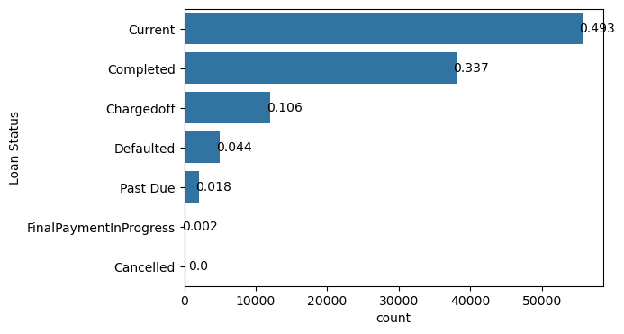

```python
# set color
base_color = sns.color_palette()[0]

# plot histogram of 'LoanStatus'
fig = plt.figure(figsize=[6, 4])
status_counts = loan_clean.LoanStatus.value_counts().copy()
type_order = loan_clean.LoanStatus.value_counts().index
sns.countplot(data = loan_clean, y = 'LoanStatus', color = base_color, order = type_order)
plt.ylabel('Loan Status')

for i in range(len(status_counts)):
    count = status_counts[i]
    per = round(count / loan_clean.shape[0], 3)
    plt.text(i+count+2000, i, per, ha = 'center', va = 'center')
plt.show()
```

### Observation 1: The distribution of Loan Status

> - Nearly half (49.3%) of all loans were in progress when Prosper Loan dataset was done.
> - 33.7% of all loans were completed.
> - 10.6% of all loans were charged off.
> - 4.4% of all loans were defaulted.
> - 1.8% of all loans passed the due date.
> - 0.2% of all loans were in final payment or cancelled.
> - The failed loans (Changed Off, Defaulted, Past Due, Cancelled) account for 17% of all loans, which is the half of the percentage of Completed loans.

### Question 2: What is the distribution of Borrower's APR or interest rate?

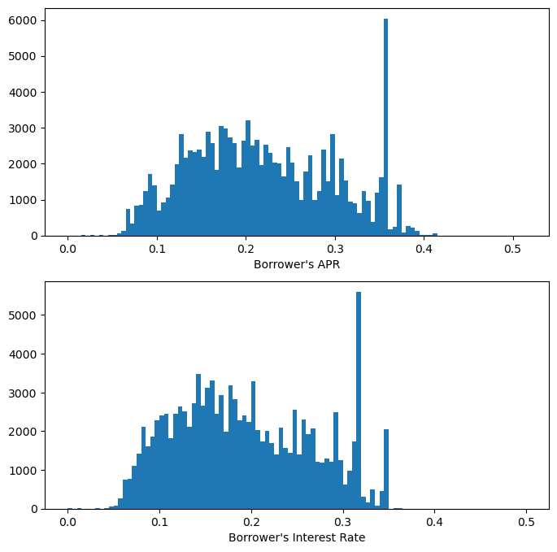

```python
fig, ax = plt.subplots(nrows = 2, figsize = [8, 8])

binsize = 0.005
bins = np.arange(0, loan_clean['BorrowerAPR'].max()+binsize, binsize)
ax[0].hist(data = loan_clean, x = 'BorrowerAPR', bins = bins)
ax[0].set_xlabel('Borrower\'s APR')

bins = np.arange(0, loan_clean['BorrowerRate'].max()+binsize, binsize)
ax[1].hist(data = loan_clean, x = 'BorrowerRate', bins = bins)
ax[1].set_xlabel('Borrower\'s Interest Rate')

plt.show()
```

### Question 3: How much do borrowers ask for originally?

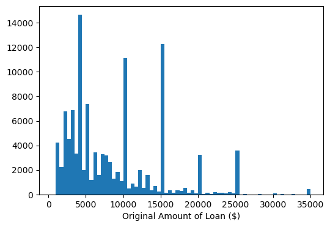

```python
fig = plt.figure(figsize = [6, 4])

binsize = 500
bins = np.arange(500, loan_clean['LoanOriginalAmount'].max()+binsize, binsize)
plt.hist(data = loan_clean, x = 'LoanOriginalAmount', bins = bins)
plt.xlabel('Original Amount of Loan ($)')
plt.show()
```

The right skewed plot shows the majority of the loans are under 15000. A logarithmic scale can be used to redisplay this plot.

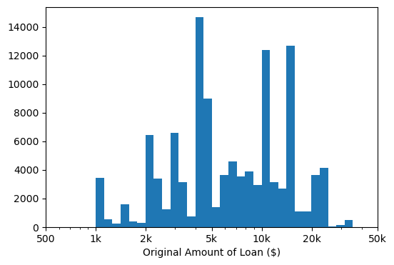

```python
fig = plt.figure(figsize = [6, 4])

binsize = 0.05
bins = 10 ** np.arange(3, np.log10(loan_clean['LoanOriginalAmount'].max())+binsize, binsize)
plt.hist(data = loan_clean, x = 'LoanOriginalAmount', bins = bins)
plt.xscale('log')
plt.xticks([500, 1000, 2000, 5000, 10000, 20000, 50000], ['500', '1k', '2k', '5k', '10k', '20k', '50k'])
plt.xlabel('Original Amount of Loan ($)')
plt.show()
```

### Observation 3: The distribution of `LoanOriginalAmount`

> - The distribution is multimodal with peaks at 4000, 10000, 15000. There are also smaller peaks at 20000 and 25000.
> - The distribution is also right skewed which means a lot of loan are with the amount under 15k.
> - By using logarithmic scale in x axis, the distribution of this feature looks more uniform and more details in the range between 1k and 10k are revealed.

### Question 4: How long do the loans last?

```python
loan_clean['Term'] = loan_clean['Term'].astype(str) + ' Months'
loan_clean.Term.unique()
```

```
array(['36 Months', '60 Months', '12 Months'], dtype=object)
```

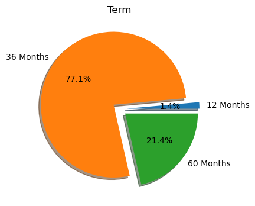

```python
fig = plt.figure(figsize = [4, 4])
p = loan_clean.groupby('Term')['Term'].count()
plt.pie(p, labels = p.index, shadow= True, explode=(0.1, 0.1, 0.1), autopct="%1.1F%%")
plt.title('Term')
plt.show()
```

### Observation 4

> - Altogether there are three options for loan term: 12 months, 36 months, and 60 months.
> - Most loans (77.1%) last 36 months. 60 months option is the second popular. Only 1.4% of all loans last 12 months.

### Question 5: How much do the borrowers have to pay back every month?

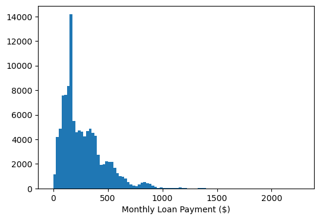

```python
fig = plt.figure(figsize = [6, 4])

binsize = 25
bins = np.arange(0-binsize, loan_clean['MonthlyLoanPayment'].max()+binsize, binsize)
plt.hist(data = loan_clean, x = 'MonthlyLoanPayment', bins = bins)
plt.xlabel('Monthly Loan Payment ($)')
plt.show()
```

Since the plot is highly right skewed, the range of X axis will be limited to (-100, 1000).

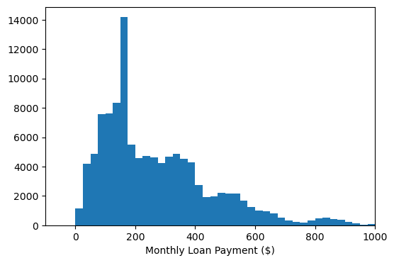

```python
fig = plt.figure(figsize = [6, 4])

binsize = 25
bins = np.arange(0-binsize, loan_clean['MonthlyLoanPayment'].max()+binsize, binsize)
plt.hist(data = loan_clean, x = 'MonthlyLoanPayment', bins = bins)
plt.xlim(-100, 1000)
plt.xlabel('Monthly Loan Payment ($)')
plt.show()
```

### Observation 5: About monthly loan payment

> - Most borrowers make monthly loan payment in the range of 0-400 dollars. 150-175 dollars is the most common monthly loan payment.

### Question 6: How much do the borrowers earn?

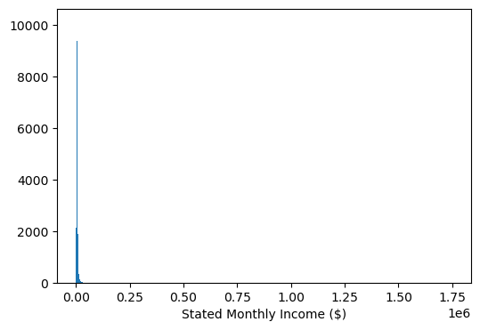

```python
fig = plt.figure(figsize = [6, 4])

binsize = 500
bins = np.arange(0, loan_clean['StatedMonthlyIncome'].max()+binsize, binsize)
plt.hist(data = loan_clean, x = 'StatedMonthlyIncome', bins = bins)
plt.xlabel('Stated Monthly Income ($)')
plt.show()
```

The plot has been pushed to a very narrow area on the left, which suggests some outliers on the right. By checking the descriptive statistic of this feature, 75% of the values are under 6824, but the maximun value is 1,750,000. I'll limit the range of X axis to (0, 15000).

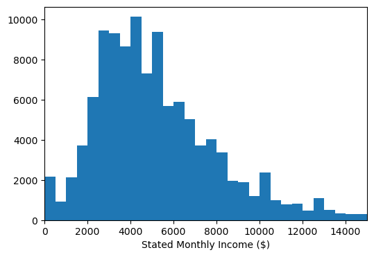

```python
fig = plt.figure(figsize = [6, 4])

binsize = 500
bins = np.arange(0, loan_clean['StatedMonthlyIncome'].max()+binsize, binsize)
plt.hist(data = loan_clean, x = 'StatedMonthlyIncome', bins = bins)
plt.xlim(0, 15000)
plt.xlabel('Stated Monthly Income ($)')
plt.show()
```

### Observation 6

> - The maximum value of this feature is 1,750,000 and it is an outlier which makes the plot heavily skewed.
> - 75% of the loan applicants have monthly income lower than 6824.
> - By set the range of X axis to (0, 15000), more details of the distribution are revealed. Most loan applicants have monthly income between 2000 and 6000.

### Question 7: What's the most popular occupation in the borrowers?

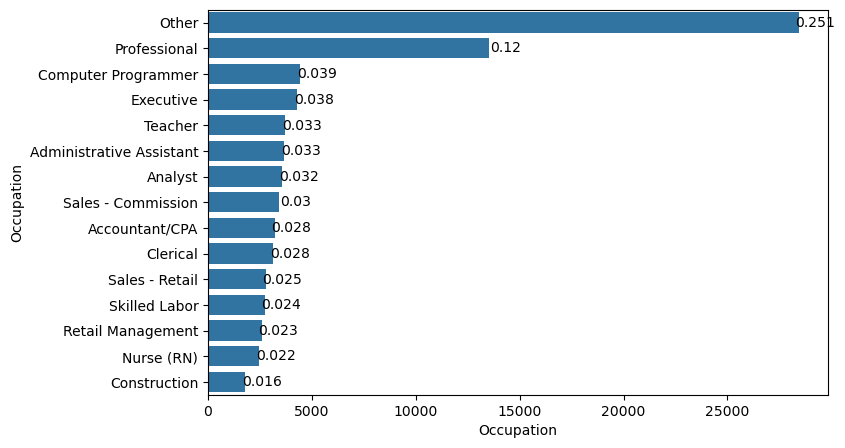

```python
fig = plt.figure(figsize=[8, 5])
type_order = loan_clean.Occupation.value_counts().iloc[:15].index
sns.countplot(data = loan_clean, y = 'Occupation', color = base_color, order = type_order)
plt.xlabel('Occupation')

counts = loan_clean.Occupation.value_counts().iloc[:15]
for i in range(15):
    count = counts[i]
    per = round(count / loan_clean.shape[0], 3)
    plt.text(count+800, i, per, ha = 'center', va = 'center')
plt.show()
```

### Observation 7

> - Because there are too many categories for `Occupation` feature, here just display the top 15 occupations.
> - 25% borrowers choose their occupation as "Other".
> - 12% borrowers choose their occupation as "Professional".
> - The number of borrower who said their occupation is "Computer Programmer" is only slightly more than the number of borrower whose occupation is "Executive".
> - "Teacher", "Administrative Assistant", "Analyst" are also quite popular among the borrowers.
> - The categories in this feature need some clarification. For example, "Professional" is too general and can include many other categories like "Computer Programmer", "Accountant/CPA", "Analyst" etc.

### Question 8: What are the employment status of the borrowers?

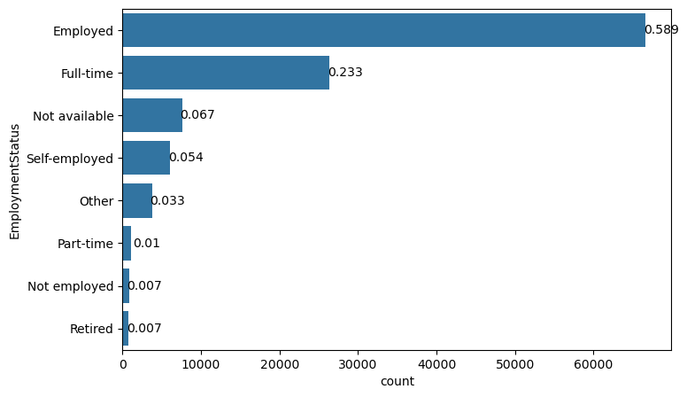

```python
fig = plt.figure(figsize=[8, 5])
type_order = loan_clean.EmploymentStatus.value_counts().index
sns.countplot(data = loan_clean, y = 'EmploymentStatus', color = base_color, order = type_order)
# sns.countplot(data = loan_clean, y = 'EmploymentStatus', color = base_color)

counts = loan_clean.EmploymentStatus.value_counts().iloc[:]
for i in range(len(counts)):
    count = counts[i]
    per = round(count / loan_clean.shape[0], 3)
    plt.text(count+2000, i, per, ha = 'center', va = 'center')
plt.show()
```

### Observation 8

> - More than half (58.9%) of the borrowers are employed.
> - Adding the categories of "Not employed", "Not available" and "Other", about 10.7% of the borrowers have uncertain employment status.
> - The percentage of full-time worker (23.3%) are much more than part-time worker (1%) and self-employed people (5.4%).
> - Some categories of this feature are overlapping. For example, "Full-time" and "Part-time" can be included in "Employed". This design defect makes the analysis of borrowers' employment status less convincing.

### Question 9: How is the rating of the borrowers by Prosper?

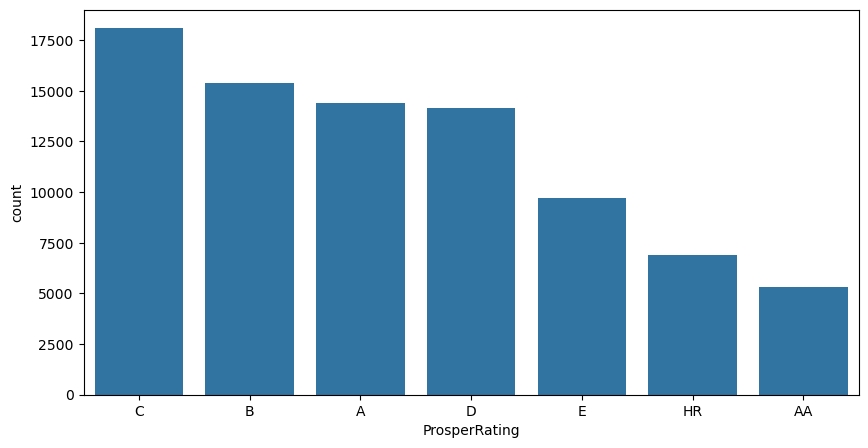

```python
type_order = loan_clean.ProsperRating.value_counts().iloc[1:].index
fig = plt.figure(figsize=[10, 5])
sns.countplot(data = loan_clean, x = 'ProsperRating', color = base_color, order = type_order)
plt.show()
```

### Observation 9

> - This plot does not display category "N/A" because this feature is only applicable for loans originated after July 2009. And this plot just displays the ratings of the borrowers who applied for loans after July 2009.
> - Most ratings are in the middle range of "A"-"D" with "C" as the most often rating.
> - "HR" is the worst rating and "AA" is the best rating, both of which remains lower than other ratings.

### Question 10: Why do people want to borrow through Prosper?

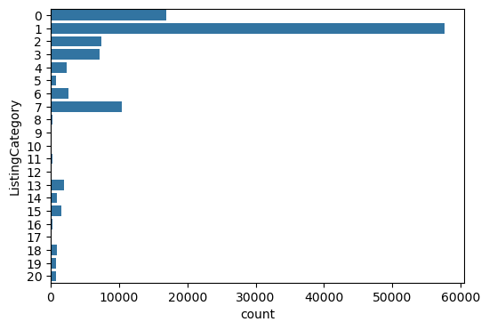

```python
fig = plt.figure(figsize = [6, 4])
sns.countplot(data = loan_clean, y = 'ListingCategory', color = base_color)
plt.show()
```

### Observation 10

> - According to the documentation: 0 - Not Available, 1 - Debt Consolidation, 2 - Home Improvement, 3 - Business, 4 - Personal Loan, 5 - Student Use, 6 - Auto, 7- Other, 8 - Baby&Adoption, 9 - Boat, 10 - Cosmetic Procedure, 11 - Engagement Ring, 12 - Green Loans, 13 - Household Expenses, 14 - Large Purchases, 15 - Medical/Dental, 16 - Motorcycle, 17 - RV, 18 - Taxes, 19 - Vacation, 20 - Wedding Loans
> - The top 5 categories to borrow are "Debt Consolidation", "Not Available", "Other", "Home Improvement", and "Business". Debt consolidation is far more than any other types which means a lot of borrowers in Prosper have already got debts and it is easier for them to get loans through Prosper than other places.

### Of the features you investigated, were there any unusual distributions? Did you perform any operations on the data to tidy, adjust, or change the form of the data? If so, why did you do this?

> - The distribution of `LoanOriginalAmount` is right skewed which means a lot of loan are with the amount under 15k. By using logarithmic scale in X axis, the distribution of this feature looks more uniform and more details in the range between 1k and 10k are revealed.

## Bivariate Exploration

### Question 11: Which numerical variables are correlated?

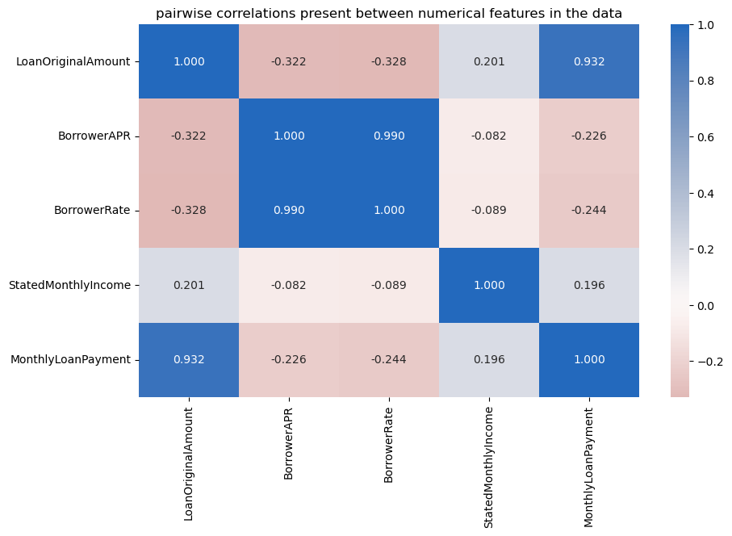

```python
numeric_vars = ['LoanOriginalAmount', 'BorrowerAPR', 'BorrowerRate', 'StatedMonthlyIncome', 'MonthlyLoanPayment']

# correlation plot
plt.figure(figsize = [10, 6])
sns.heatmap(loan_clean[numeric_vars].corr(), annot = True, fmt = '.3f',
           cmap = 'vlag_r', center = 0)
plt.title("pairwise correlations present between numerical features in the data")
plt.show()
```

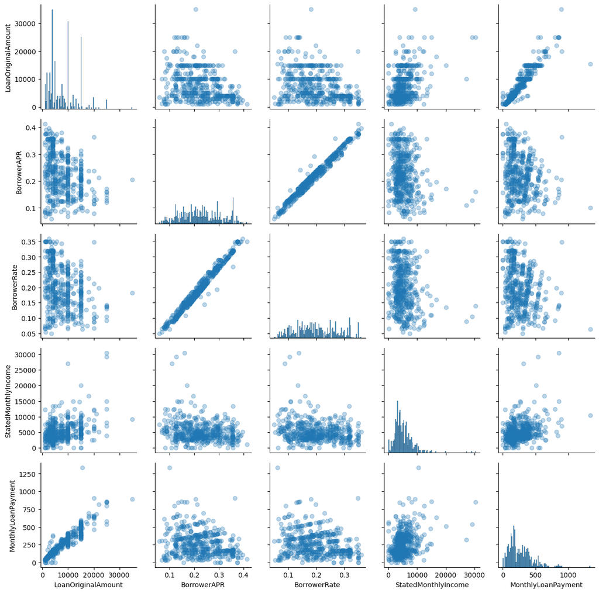

```python
# plot matrix: sample 500 loans so that plots are clearer and they render faster
loan_samp = loan_clean.sample(500)

g = sns.PairGrid(data = loan_samp, vars = numeric_vars)
g = g.map_diag(sns.histplot, bins=100);
g.map_offdiag(plt.scatter, alpha=0.3);
plt.show()
```

### Observation 11

> - There is strong correlation between `LoanOriginalAmount` and `MonthlyLoanPayment`.
> - Also as expected, `BorrowerAPR` and `BorrowerRate` are strongly correlated as well.
> - For the rest of the variables, correlation is not clear from the correlation matrix and sample's scatter plots.

Let's see the plot of all data from `MonthlyLoanPayment` and `LoanOriginalAmount`.

### Question 12: What does the relationship between `MonthlyLoanPayment` and `LoanOriginalAmount` look like?

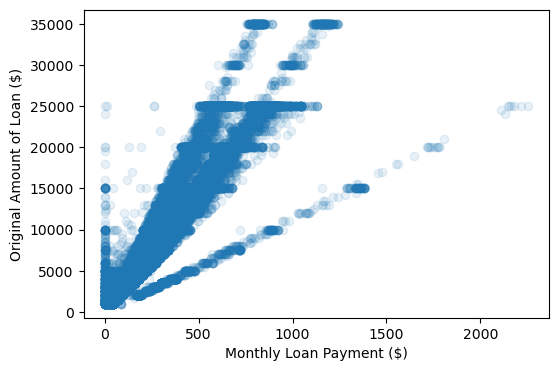

```python
fig = plt.figure(figsize = [6, 4])
plt.scatter(data = loan_clean, x = 'MonthlyLoanPayment', y = 'LoanOriginalAmount', alpha = 1/10)
plt.ylabel('Original Amount of Loan ($)')
plt.xlabel('Monthly Loan Payment ($)')
plt.show()
```

### Observation 12

> - Although these two variables are strongly correlated, the scatter plot displays 4 lines with different slopes.
> - This leads to a question: what causes these line patterns?

### Question 13: Does the Prosper rating affects borrower's interest rate?

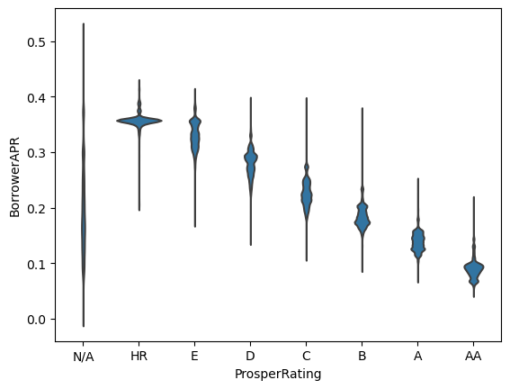

```python
sns.violinplot(data = loan_clean, x = 'ProsperRating', y = 'BorrowerAPR', color = base_color, inner = None)
plt.show()
```

### Observation 13

> It is obvious that the better the Prosper Rating is, the lower the APR is. A good rating can significantly reduce the interest rate for the borrower.

### Question 14: Does borrower's employment status affects his interest rate?

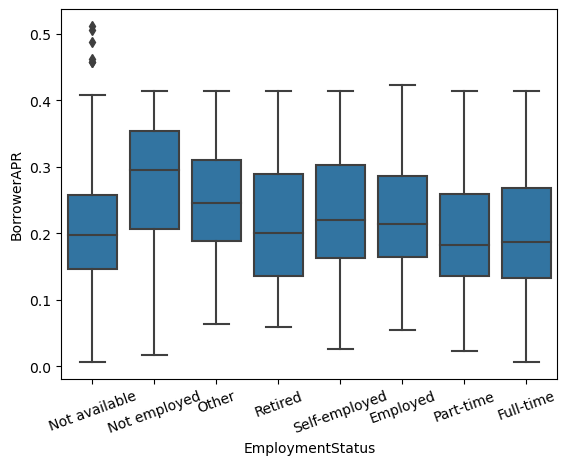

```python
sns.boxplot(data = loan_clean, x = 'EmploymentStatus', y = 'BorrowerAPR', color = base_color)
plt.xticks(rotation = 20)
plt.show()
```

### Observation 14

> - People who are not employed have to pay for higher APR.
> - For the rest of the groups, the difference is not as obvious as the unemployed borrowers.

### Question 15: Is the loan' status affected by borrowers' employment status?

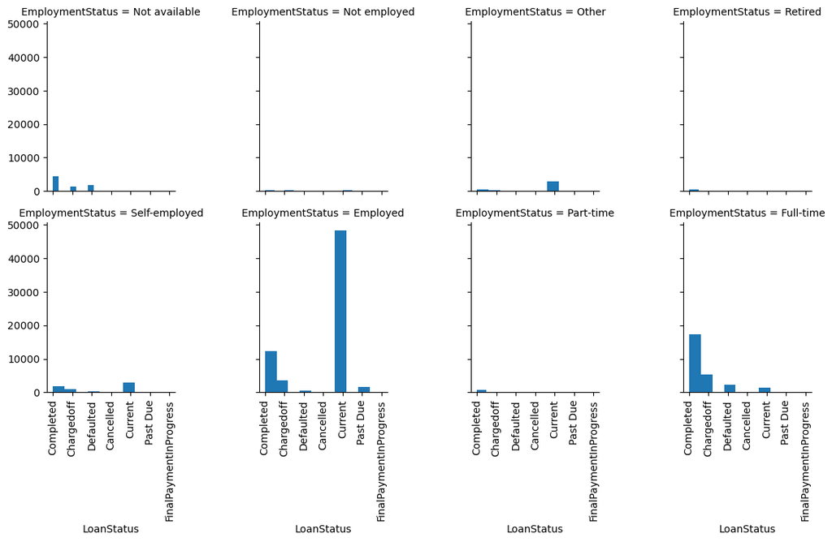

```python
g = sns.FacetGrid(data = loan_clean, col = 'EmploymentStatus', col_wrap = 4, sharey = True)
g.map(plt.hist, "LoanStatus")
g.set_xticklabels(rotation=90)
plt.show()
```

### Observation 15

> - It is very obvious that the borrowers with stable employment status have much higher chance to get and complete their loans.

### Talk about some of the relationships you observed in this part of the investigation. How did the feature(s) of interest vary with other features in the dataset?

> - As expected, `BorrowerAPR` and `BorrowerRate` have strong positive correlation. For the rest of the numerical variables, correlation is not clear from the correlation matrix and sample's scatter plots.
> - The Prosper rating can affect the borrowers' APR significantly. The better the Prosper Rating, the lower the borrower's APR. A good rating can significantly reduce the interest rate for the borrower.
> - Borrowers who are not employed have to pay with higher APR. However for the rest of the groups, e.g. full-time and part-time, the effect is not as obvious as the unemployed borrowers.
> - The borrowers with stable employment status, like "Employed" and "Full-time", have much higher chance to get and complete their loans.

### Did you observe any interesting relationships between the other features (not the main feature(s) of interest)?

> - There is strong correlation between `LoanOriginalAmount` and `MonthlyLoanPayment`. Although they are strongly correlated, the scatter plot displays several lines with different slopes. This leads to a question: what causes these line patterns?

## Multivariate Exploration

### Question 16: Does `Term` play a part on the relationship between `MonthlyLoanPayment` and `LoanOriginalAmount`?

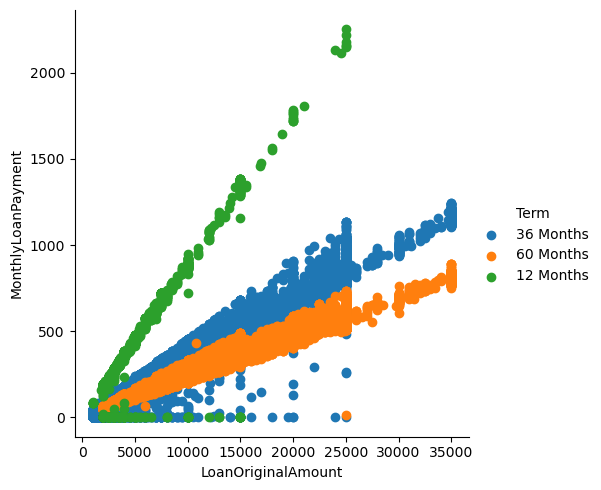

```python
g = sns.FacetGrid(data = loan_clean, hue = 'Term', height = 5)
g.map(plt.scatter, 'LoanOriginalAmount', 'MonthlyLoanPayment')
g.add_legend()
plt.show()
```

### Were there any interesting or surprising interactions between features?

> The correlation matrix and scatter plot matrix shown in Question 11 can be also counted as multivariate exploration. Most of the correlation coefficients do not suggest strong correlation and this has been verified in the scatter plots. To improve this project, new features need to be added for exploration.

## Conclusions

This notebook tries to answer the questions about who and why borrows through Prosper and what affect the borrowers' APR or interest rates.

In bivariate exploration, we find monthly loan payment has strong correlation with loan's original amount. But the scatter plot of these features shows a few straight line patterns with different slopes. This has been explained by multivariate exploration and the different line patterns are caused by different length of the loan ("Term" feature).

We also find the borrowers' APR are significantly affected by their Prosper ratings. The higher the rating, the lower the APR. And the borrowers' employment status play a part in APR as well. For unemployed people, they have to afford higher APR.